# Analyses - paper FunctionalLands

*Lacandona*

```
## The model including the effect 'FC_500ha' was the best model according to the specified criterion (R2, which.max)
```

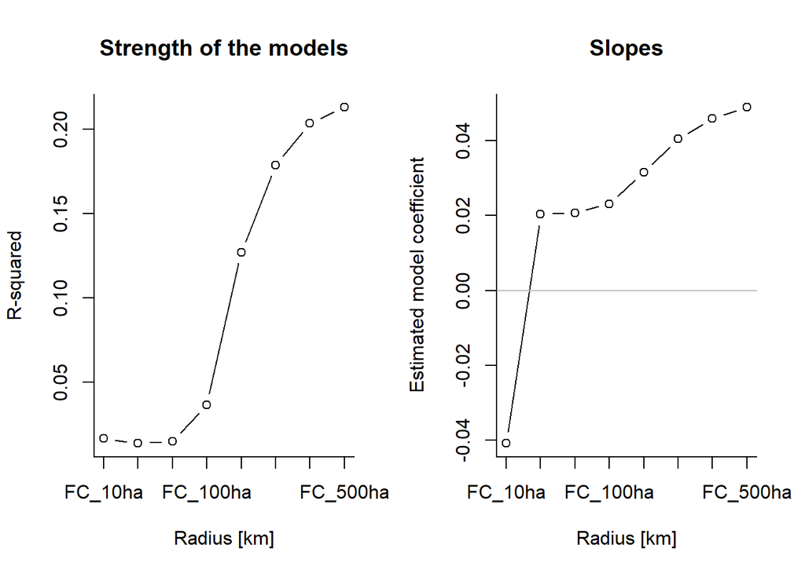

```r
Fdis_FC_LCD <- multifit(mod = "lm", multief = colnames(data_LCD)[19:26],
                        formula = SES_Fdis ~ multief+I(multief^2),
                        data = data_LCD, criterion = "R2", plot_est = T)
```

*Los Tuxtlas*

```
## The model including the effect 'FC_10ha' was the best model according to the specified criterion (R2, which.max)
```

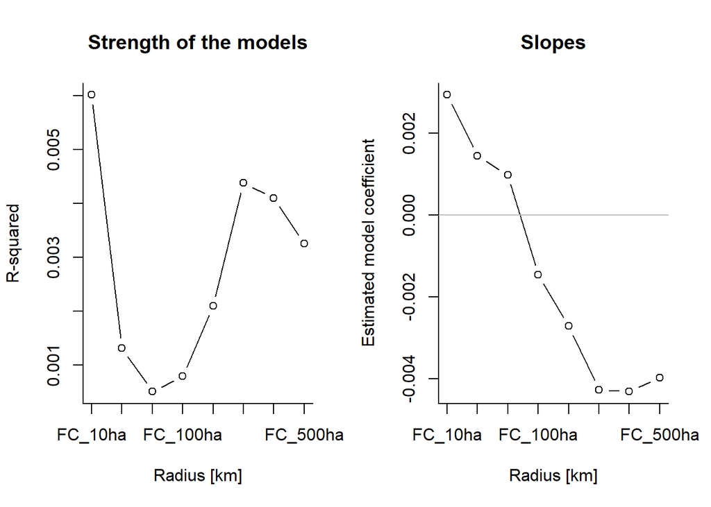

```r
Fdis_FC_LTX <- multifit(mod = "lm", multief = colnames(data_LTX)[19:26],
                        formula = SES_Fdis ~ multief,
                        data = data_LTX, criterion = "R2", plot_est = T)
```

*Balbina*

```
## The model including the effect 'FC_100ha' was the best model according to the specified criterion (R2, which.max)
```

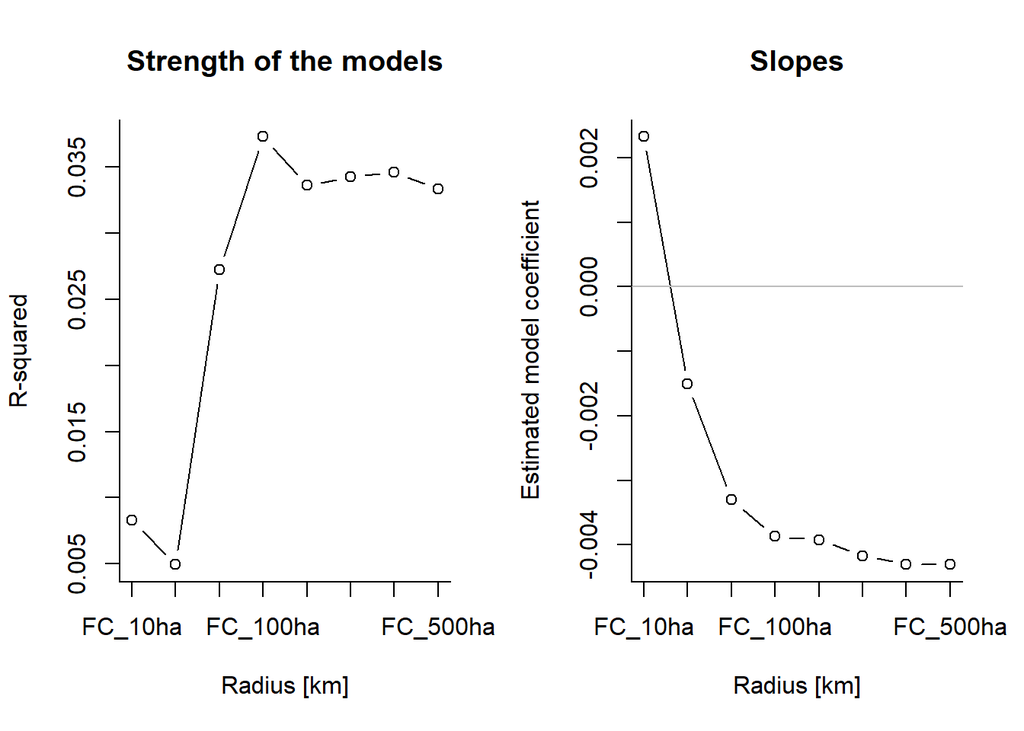

```r
Fdis_FC_Balb<- multifit(mod = "lm", multief = colnames(data_Balb)[19:26],
                        formula = SES_Fdis ~ multief,
                        data = data_Balb, criterion = "R2", plot_est = T)
```

*Paraiba*

```
## The model including the effect 'FC_500ha' was the best model according to the specified criterion (R2, which.max)
```

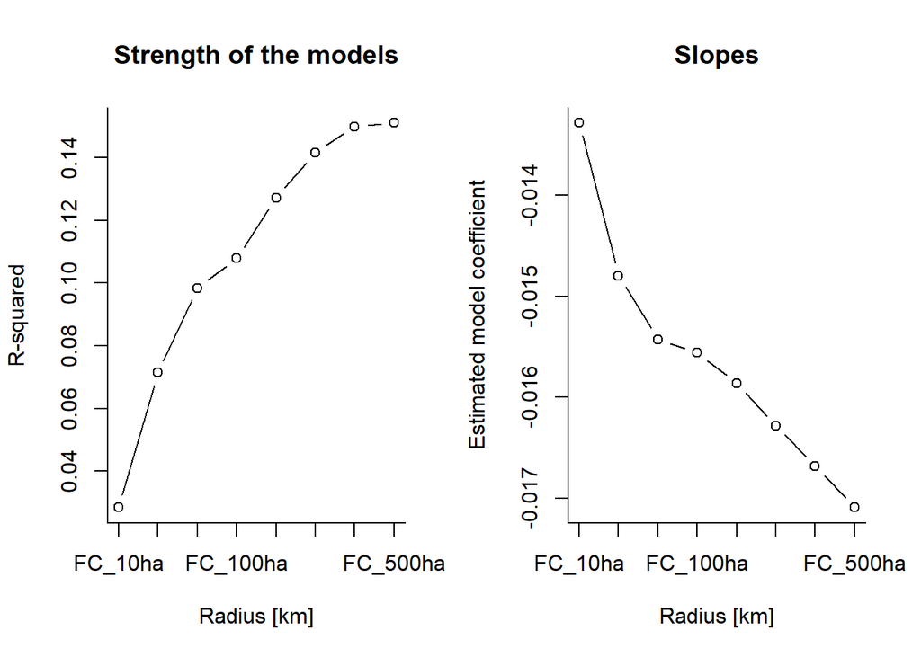

```r
Fdis_FC_PB<- multifit(mod = "lm", multief = colnames(data_PB)[19:26],
                      formula = SES_Fdis ~ multief,
                      data = data_PB, criterion = "R2", plot_est = T)
```

*Serra Grande*

```
## The model including the effect 'FC_300ha' was the best model according to the specified criterion (R2, which.max)
```

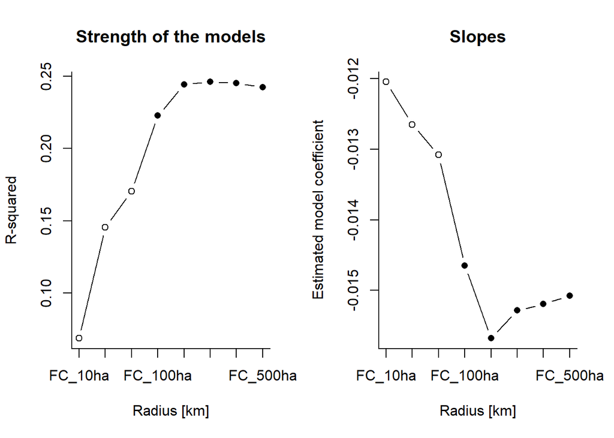

```r
Fdis_FC_SGD<- multifit(mod = "lm", multief = colnames(data_SGD)[19:26],
                       formula = SES_Fdis ~ multief,
                       data = data_SGD, criterion = "R2", plot_est = T)
```

*Una*

```
## The model including the effect 'FC_100ha' was the best model according to the specified criterion (R2, which.max)
```

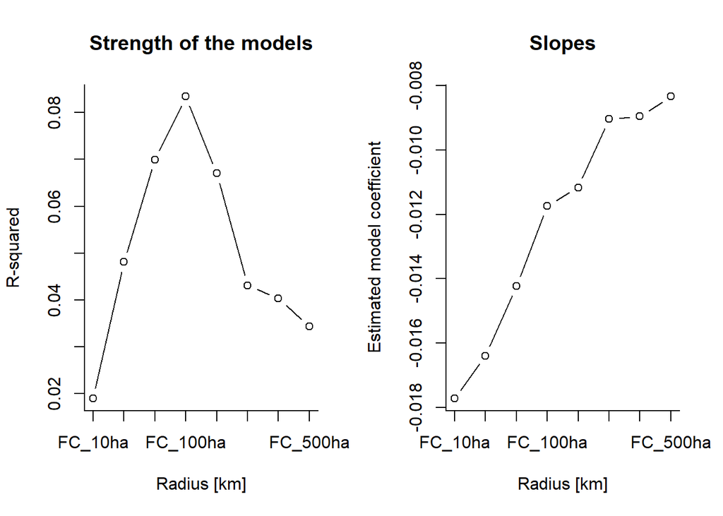

```r
Fdis_FC_Una<- multifit(mod = "lm", multief = colnames(data_Una)[19:26],
                       formula = SES_Fdis ~ multief,
                       data = data_Una, criterion = "R2", plot_est = T)
```

*Serra Tabuleiro*

```
## The model including the effect 'FC_100ha' was the best model according to the specified criterion (R2, which.max)
```

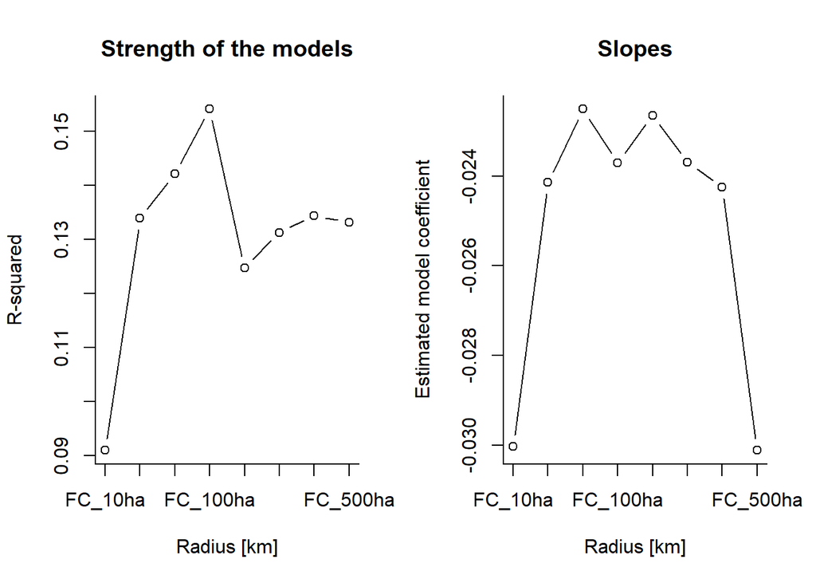

```r
Fdis_FC_STB<- multifit(mod = "lm", multief = colnames(data_STB)[19:26],
                       formula = SES_Fdis ~ multief,
                       data = data_STB, criterion = "R2", plot_est = T)
```

**Get estimates, R2 and p-values at different scales/region**

```r
###LTX
results_LTX <- rbind.data.frame(WD_FC_LTX$summary, SLA_FC_LTX$summary, SM_FC_LTX$summary, Fric_FC_LTX$summary, Fdis_FC_LTX$summary)
results_LTX$response <- c(rep("WD", 8), rep("SLA", 8), rep("SM", 8), rep("Fric", 8), rep("Fdis", 8))
results_LTX$Region <- rep("LTX", 40)


###LCD
results_LCD <- rbind.data.frame(WD_FC_LCD$summary, SLA_FC_LCD$summary, SM_FC_LCD$summary, Fric_FC_LCD$summary, Fdis_FC_LCD$summary)
results_LCD$response <- c(rep("WD", 8), rep("SLA", 8), rep("SM", 8), rep("Fric", 8), rep("Fdis", 8))
results_LCD$Region <- rep("LCD", 40)

###Balbina
results_Balb <- rbind.data.frame(WD_FC_Balb$summary, SLA_FC_Balb$summary, SM_FC_Balb$summary,Fric_FC_Balb$summary, Fdis_FC_Balb$summary)
results_Balb$response <- c(rep("WD", 8), rep("SLA", 8), rep("SM", 8), rep("Fric", 8), rep("Fdis", 8))
results_Balb$Region <- rep("Balb", 40)

###PB
results_PB <- rbind.data.frame(WD_FC_PB$summary, SLA_FC_PB$summary, SM_FC_PB$summary, Fric_FC_PB$summary, Fdis_FC_PB$summary)
results_PB$response <- c(rep("WD", 8), rep("SLA", 8), rep("SM", 8), rep("Fric", 8), rep("Fdis", 8))
results_PB$Region <- rep("PB", 40)

###SGD
results_SGD <- rbind.data.frame(WD_FC_SGD$summary, SLA_FC_SGD$summary, SM_FC_SGD$summary, Fric_FC_SGD$summary, Fdis_FC_SGD$summary)
results_SGD$response <- c(rep("WD", 8), rep("SLA", 8), rep("SM", 8), rep("Fric", 8), rep("Fdis", 8))
results_SGD$Region <- rep("SGD", 40)

###Una
results_Una <- rbind.data.frame(WD_FC_Una$summary, SLA_FC_Una$summary, SM_FC_Una$summary, Fric_FC_Una$summary, Fdis_FC_Una$summary)
results_Una$response <- c(rep("WD", 8), rep("SLA", 8), rep("SM", 8), rep("Fric", 8), rep("Fdis", 8))
results_Una$Region <- rep("Una", 40)

###STB
results_STB <- rbind.data.frame(WD_FC_STB$summary, SLA_FC_STB$summary, SM_FC_STB$summary, Fric_FC_STB$summary, Fdis_FC_STB$summary)
results_STB$response <- c(rep("WD", 8), rep("SLA", 8), rep("SM", 8), rep("Fric", 8), rep("Fdis", 8))
results_STB$Region <- rep("STB", 40)

results_SE_all <- rbind.data.frame(results_LTX, results_LCD, results_Balb, results_PB,
                                   results_SGD, results_Una, results_STB)
```

**Plot scales of effect by trait/region** *(filled points denote significant relationships at the specified scale)*

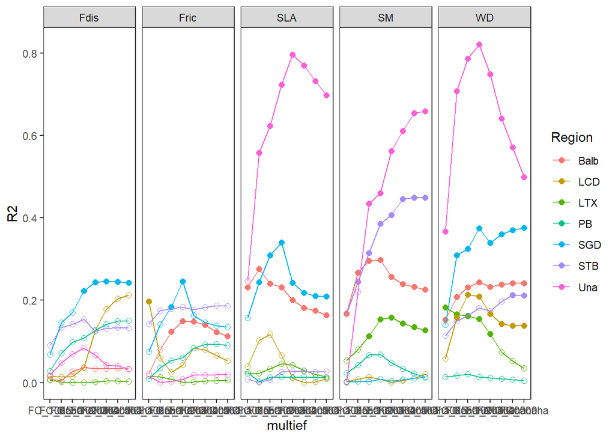

```r
ggplot(data=results_SE_all, aes(x = multief, y = R2, color = Region, group=Region))+
  geom_point(data=filter(results_SE_all, p.values > 0.05), shape=1, size=2)+
  geom_point(data=filter(results_SE_all, p.values <= 0.05), size=2)+
  geom_line(aes(multief, R2))+theme_bw()+
  theme(plot.background = element_blank(),panel.grid.major = element_blank(),panel.grid.minor = element_blank())+
  facet_grid( ~ response)
```

**Another option of plots to show trait-landscape relationships: scatterplots with varying slopes by Region** *(below examples at 100ha scale)*

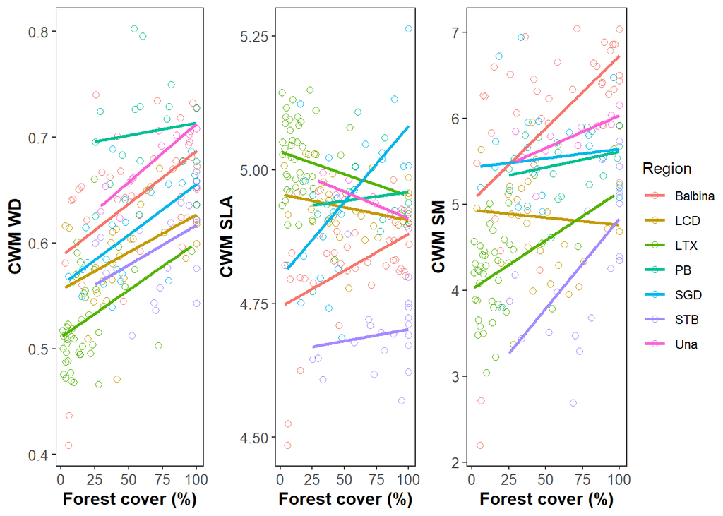

```r
p_WD_FC100 <- ggplot(data = data_lands, aes(x=FC_100ha, y=WD, colour=Region))+geom_point(shape=1, size=2)+geom_smooth(method="lm", aes(FC_100ha,WD, group=Region), na.rm = TRUE, se=FALSE)+theme_bw()+ylab("CWM WD")+xlab("Forest cover (%)")+
  theme(axis.text = element_text(size=10), axis.title = element_text(size=12, face = "bold"))+
  theme(plot.background = element_blank(),panel.grid.major = element_blank(),panel.grid.minor = element_blank())

p_SLA_FC100 <- ggplot(data = data_lands, aes(x=FC_100ha, y=SLA, colour=Region))+geom_point(shape=1, size=2)+geom_smooth(data = data_lands, method="lm", aes(FC_100ha,SLA, group=Region), na.rm = TRUE, se=FALSE)+theme_bw()+ylab("CWM SLA")+xlab("Forest cover (%)")+
  theme(axis.text = element_text(size=10), axis.title = element_text(size=12, face = "bold"))+
  theme(plot.background = element_blank(),panel.grid.major = element_blank(),panel.grid.minor = element_blank())

p_SM_FC100 <- ggplot(data = data_lands, aes(x=FC_100ha, y=SM, colour=Region))+geom_point(shape=1, size=2)+geom_smooth(data = data_lands, method="lm", aes(FC_100ha,SM, group=Region), na.rm = TRUE, se=FALSE)+theme_bw()+ylab("CWM SM")+xlab("Forest cover (%)")+
  theme(axis.text = element_text(size=10), axis.title = element_text(size=12, face = "bold"))+
  theme(plot.background = element_blank(),panel.grid.major = element_blank(),panel.grid.minor = element_blank())

ggarrange(p_WD_FC100, p_SLA_FC100, p_SM_FC100, nrow = 1, ncol = 3, common.legend = TRUE, legend = "right", align = "h")
```

**Run lm and plot model estimates for each trait/scale** *(actually, only three scales are shown - I still need to figure out how to include the different estimates in a single plot, highlighting the one representing the scale of effect for each region)*

**WD**

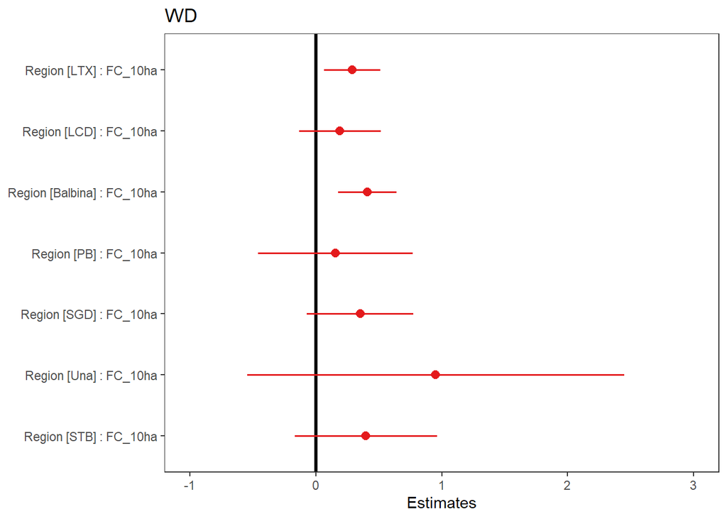

```r
WD10 <- lm(WD ~ Region+FC_10ha:Region, data = data_lands)
plot_model(WD10, type = "std", vline.color = "black", show.p = TRUE, terms = c("RegionLTX:FC_10ha", "RegionLCD:FC_10ha", "RegionBalbina:FC_10ha",                  "RegionPB:FC_10ha", "RegionSGD:FC_10ha", "RegionUna:FC_10ha", "RegionSTB:FC_10ha"),
           order.terms = c(3,2,1,4,5,7,6))+theme_bw()+theme(plot.background = element_blank(),panel.grid.major = element_blank(),panel.grid.minor = element_blank())
```

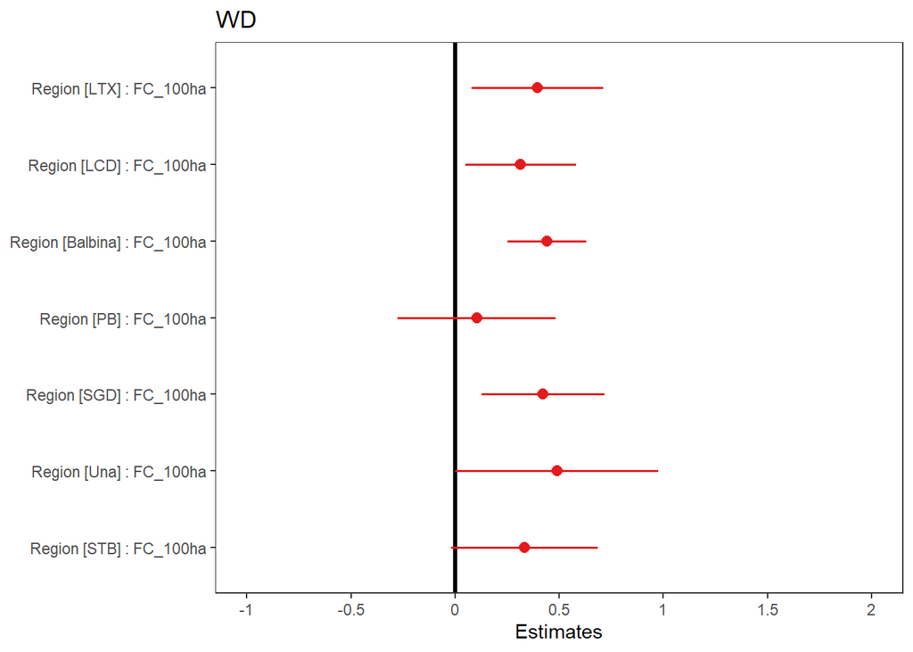

```r
WD100 <- lm(WD ~ Region+FC_100ha:Region, data = data_lands)
plot_model(WD100, type = "std", vline.color = "black", show.p = TRUE, terms = c("RegionLTX:FC_100ha", "RegionLCD:FC_100ha", "RegionBalbina:FC_100ha",                  "RegionPB:FC_100ha", "RegionSGD:FC_100ha", "RegionUna:FC_100ha", "RegionSTB:FC_100ha"),
           order.terms = c(3,2,1,4,5,7,6))+theme_bw()+theme(plot.background = element_blank(),panel.grid.major = element_blank(),panel.grid.minor = element_blank())
```

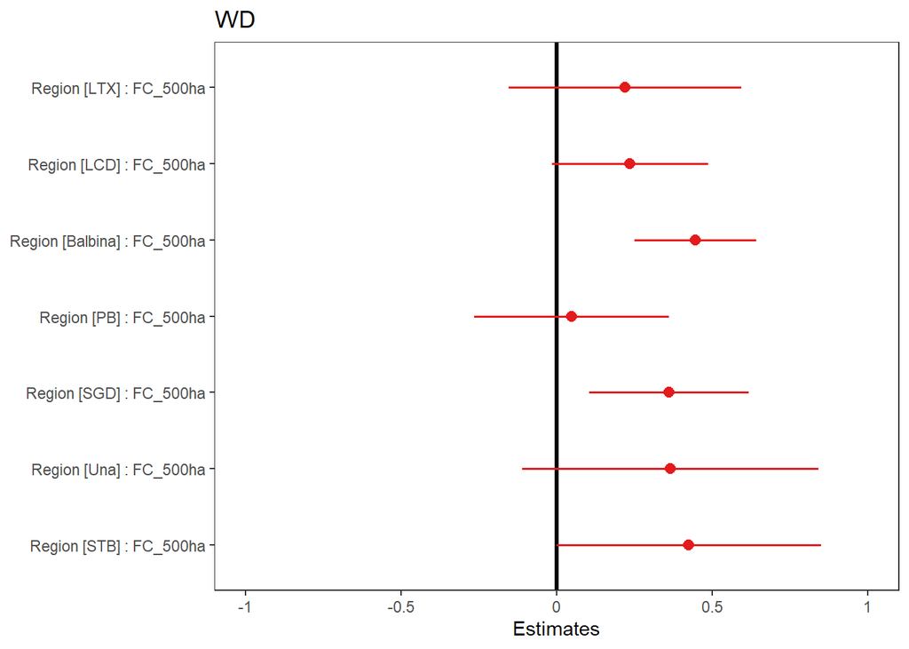

```r
WD500 <- lm(WD ~ Region+FC_500ha:Region, data = data_lands)
plot_model(WD500, type = "std", vline.color = "black", show.p = TRUE, terms = c("RegionLTX:FC_500ha", "RegionLCD:FC_500ha", "RegionBalbina:FC_500ha",                  "RegionPB:FC_500ha", "RegionSGD:FC_500ha", "RegionUna:FC_500ha", "RegionSTB:FC_500ha"),
           order.terms = c(3,2,1,4,5,7,6))+theme_bw()+theme(plot.background = element_blank(),panel.grid.major = element_blank(),panel.grid.minor = element_blank())
```

**SLA**

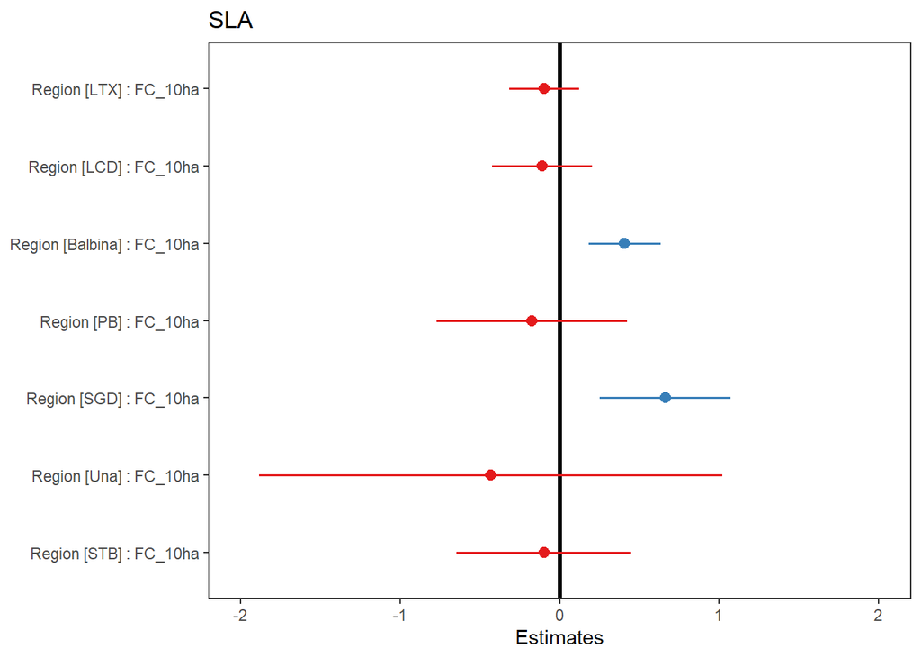

```r
SLA10 <- lm(SLA ~ Region+FC_10ha:Region, data = data_lands)
plot_model(SLA10, type = "std", vline.color = "black", show.p = TRUE, terms = c("RegionLTX:FC_10ha", "RegionLCD:FC_10ha", "RegionBalbina:FC_10ha",                  "RegionPB:FC_10ha", "RegionSGD:FC_10ha", "RegionUna:FC_10ha", "RegionSTB:FC_10ha"),
           order.terms = c(3,2,1,4,5,7,6))+theme_bw()+theme(plot.background = element_blank(),panel.grid.major = element_blank(),panel.grid.minor = element_blank())
```

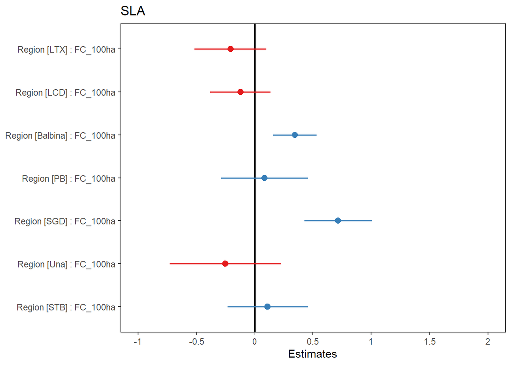

```r
SLA100 <- lm(SLA ~ Region+FC_100ha:Region, data = data_lands)
plot_model(SLA100, type = "std", vline.color = "black", show.p = TRUE, terms = c("RegionLTX:FC_100ha", "RegionLCD:FC_100ha", "RegionBalbina:FC_100ha",                  "RegionPB:FC_100ha", "RegionSGD:FC_100ha", "RegionUna:FC_100ha", "RegionSTB:FC_100ha"),
           order.terms = c(3,2,1,4,5,7,6))+theme_bw()+theme(plot.background = element_blank(),panel.grid.major = element_blank(),panel.grid.minor = element_blank())
```

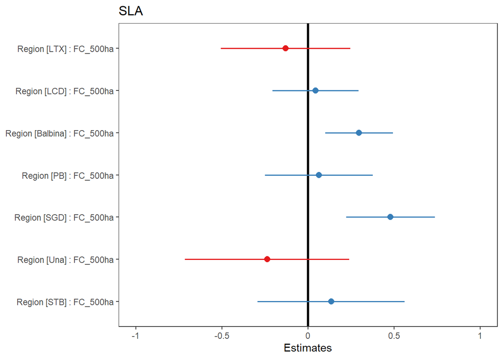

```r
SLA500 <- lm(SLA ~ Region+FC_500ha:Region, data = data_lands)
plot_model(SLA500, type = "std", vline.color = "black", show.p = TRUE, terms = c("RegionLTX:FC_500ha", "RegionLCD:FC_500ha", "RegionBalbina:FC_500ha",                  "RegionPB:FC_500ha", "RegionSGD:FC_500ha", "RegionUna:FC_500ha", "RegionSTB:FC_500ha"),
           order.terms = c(3,2,1,4,5,7,6))+theme_bw()+theme(plot.background = element_blank(),panel.grid.major = element_blank(),panel.grid.minor = element_blank())
```

**Seed mass**

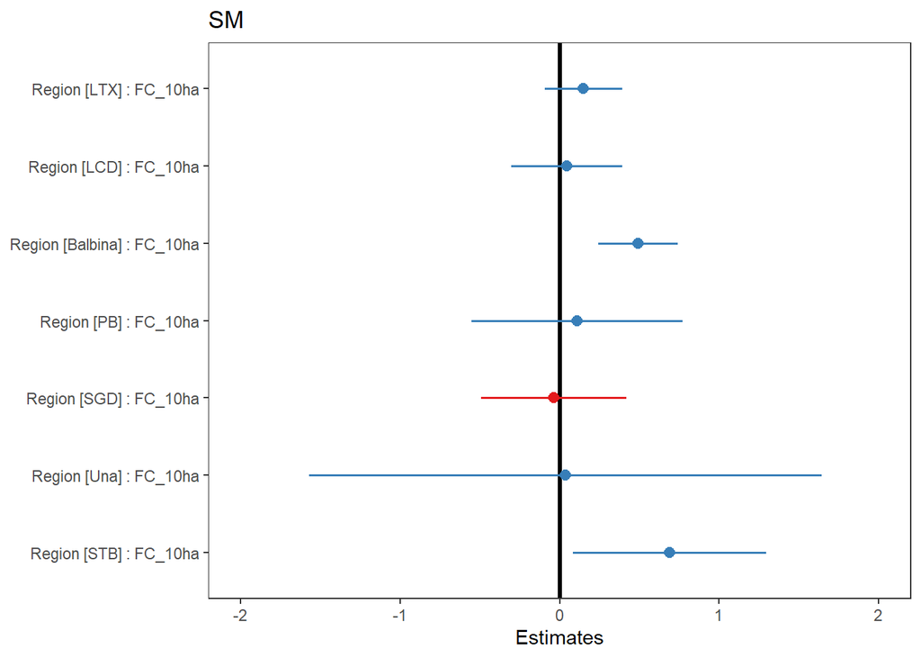

```r
SM10 <- lm(SM ~ Region+FC_10ha:Region, data = data_lands)
plot_model(SM10, type = "std", vline.color = "black", show.p = TRUE, terms = c("RegionLTX:FC_10ha", "RegionLCD:FC_10ha", "RegionBalbina:FC_10ha",                  "RegionPB:FC_10ha", "RegionSGD:FC_10ha", "RegionUna:FC_10ha", "RegionSTB:FC_10ha"),
           order.terms = c(3,2,1,4,5,7,6))+theme_bw()+theme(plot.background = element_blank(),panel.grid.major = element_blank(),panel.grid.minor = element_blank())
```

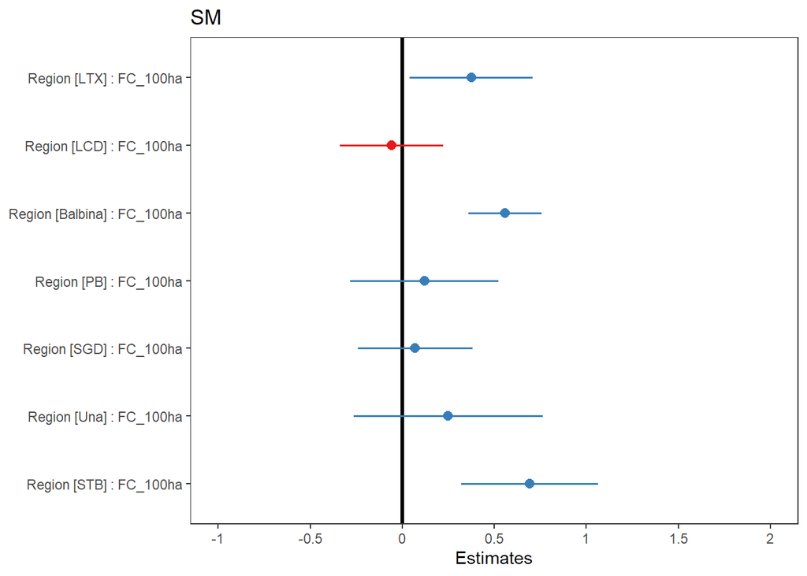

```r
SM100 <- lm(SM ~ Region+FC_100ha:Region, data = data_lands)
plot_model(SM100, type = "std", vline.color = "black", show.p = TRUE, terms = c("RegionLTX:FC_100ha", "RegionLCD:FC_100ha", "RegionBalbina:FC_100ha",                  "RegionPB:FC_100ha", "RegionSGD:FC_100ha", "RegionUna:FC_100ha", "RegionSTB:FC_100ha"),
           order.terms = c(3,2,1,4,5,7,6))+theme_bw()+theme(plot.background = element_blank(),panel.grid.major = element_blank(),panel.grid.minor = element_blank())
```

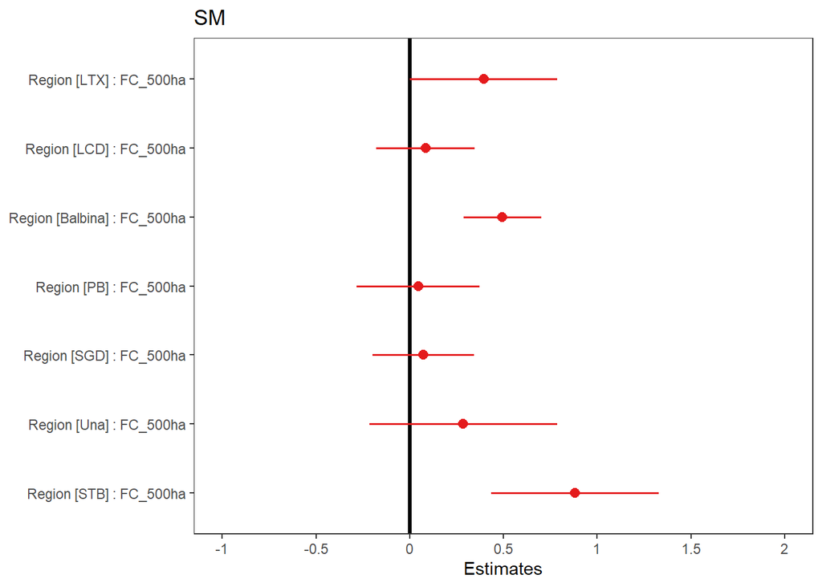

```r
SM500 <- lm(SM ~ Region+FC_500ha:Region, data = data_lands)
plot_model(SM500, type = "std", vline.color = "black", show.p = TRUE, terms = c("RegionLTX:FC_500ha", "RegionLCD:FC_500ha", "RegionBalbina:FC_500ha",                  "RegionPB:FC_500ha", "RegionSGD:FC_500ha", "RegionUna:FC_500ha", "RegionSTB:FC_500ha"),
           order.terms = c(3,2,1,4,5,7,6))+theme_bw()+theme(plot.background = element_blank(),panel.grid.major = element_blank(),panel.grid.minor = element_blank())
```

**Models trait-landscape - with selected or multiple scales followed by stepwise**

*Is there a best scale overall?*

**WD**

```r
m_WD <- lm(WD ~ FC_10ha*Region+FC_25ha*Region+FC_50ha*Region+FC_100ha*Region+FC_200ha*Region+
             FC_300ha*Region+FC_400ha*Region+FC_500ha*Region,  data = data_lands)

summary(m_WD)
```

```
##
## Call:
## lm(formula = WD ~ FC_10ha * Region + FC_25ha * Region + FC_50ha *
##     Region + FC_100ha * Region + FC_200ha * Region + FC_300ha *
##     Region + FC_400ha * Region + FC_500ha * Region, data = data_lands)
##
## Residuals:
##       Min        1Q    Median        3Q       Max
## -0.163560 -0.020835  0.000355  0.022069  0.123521
##
## Coefficients:
##                      Estimate Std. Error t value Pr(>|t|)
## (Intercept)         0.5548085  0.0287023  19.330   <2e-16 ***
## FC_10ha             0.0007839  0.0007690   1.019   0.3101
## RegionLCD           0.0346719  0.0612535   0.566   0.5724
## RegionLTX          -0.0408252  0.0340439  -1.199   0.2328
## RegionPB            0.1573009  0.1146489   1.372   0.1726
## RegionSGD           0.0752864  0.0761897   0.988   0.3251
## RegionSTB           0.1195908  0.1404446   0.852   0.3962
## RegionUna           0.5460365  1.0757450   0.508   0.6127
## FC_25ha            -0.0004796  0.0017426  -0.275   0.7836
## FC_50ha            -0.0008835  0.0030358  -0.291   0.7715
## FC_100ha            0.0040026  0.0036584   1.094   0.2761
## FC_200ha           -0.0049264  0.0044017  -1.119   0.2653
## FC_300ha           -0.0013802  0.0088336  -0.156   0.8761
## FC_400ha            0.0070018  0.0128461   0.545   0.5867
## FC_500ha           -0.0026177  0.0073319  -0.357   0.7217
## FC_10ha:RegionLCD  -0.0024411  0.0022124  -1.103   0.2721
## FC_10ha:RegionLTX  -0.0004406  0.0017016  -0.259   0.7961
## FC_10ha:RegionPB    0.0001326  0.0033002   0.040   0.9680
## FC_10ha:RegionSGD  -0.0040225  0.0021420  -1.878   0.0628 .
## FC_10ha:RegionSTB  -0.0056408  0.0042070  -1.341   0.1825
## FC_10ha:RegionUna  -0.0100399  0.0220019  -0.456   0.6490
## RegionLCD:FC_25ha   0.0015689  0.0046467   0.338   0.7362
## RegionLTX:FC_25ha  -0.0001425  0.0037558  -0.038   0.9698
## RegionPB:FC_25ha   -0.0040493  0.0066302  -0.611   0.5425
## RegionSGD:FC_25ha   0.0074773  0.0037012   2.020   0.0456 *
## RegionSTB:FC_25ha   0.0080546  0.0068739   1.172   0.2436
## RegionUna:FC_25ha   0.0083574  0.0252655   0.331   0.7414
## RegionLCD:FC_50ha   0.0025963  0.0068518   0.379   0.7054
```

[output cut: 26 more lines]

```
## RegionSGD:FC_400ha -0.0406094  0.0256246  -1.585   0.1156
## RegionSTB:FC_400ha  0.0047183  0.0751458   0.063   0.9500
## RegionUna:FC_400ha -0.0040482  0.0502189  -0.081   0.9359
## RegionLCD:FC_500ha  0.0095736  0.0130528   0.733   0.4647
## RegionLTX:FC_500ha -0.0153387  0.0132928  -1.154   0.2508
## RegionPB:FC_500ha  -0.0102742  0.0156378  -0.657   0.5124
## RegionSGD:FC_500ha  0.0150440  0.0130187   1.156   0.2501
## RegionSTB:FC_500ha -0.0092916  0.0919286  -0.101   0.9197
## RegionUna:FC_500ha -0.0071406  0.0321578  -0.222   0.8246
## ---
## Signif. codes:  0 '***' 0.001 '**' 0.01 '*' 0.05 '.' 0.1 ' ' 1
##
## Residual standard error: 0.04851 on 121 degrees of freedom
## Multiple R-squared:  0.7241, Adjusted R-squared:  0.5828
## F-statistic: 5.123 on 62 and 121 DF,  p-value: 9.148e-15
```

```r
step(m_WD, scope=list(upper=m_WD, lower= ~1), direction="both", trace=F)
```

```
##
## Call:
## lm(formula = WD ~ Region + FC_100ha + FC_300ha + FC_400ha, data = data_lands)
##
## Coefficients:
## (Intercept)    RegionLCD    RegionLTX     RegionPB    RegionSGD    RegionSTB
##    0.594765    -0.051948    -0.084897     0.056454    -0.033599    -0.067090
##   RegionUna     FC_100ha     FC_300ha     FC_400ha
##    0.016740     0.001389    -0.003747     0.003287
```

**SLA**

```r
m_SLA <- lm(SLA ~ FC_10ha*Region+FC_25ha*Region+FC_50ha*Region+FC_100ha*Region+FC_200ha*Region+
             FC_300ha*Region+FC_400ha*Region+FC_500ha*Region,  data = data_lands)

summary(m_SLA)
```

```
##
## Call:
## lm(formula = SLA ~ FC_10ha * Region + FC_25ha * Region + FC_50ha *
##     Region + FC_100ha * Region + FC_200ha * Region + FC_300ha *
##     Region + FC_400ha * Region + FC_500ha * Region, data = data_lands)
##
## Residuals:
##       Min        1Q    Median        3Q       Max
## -0.222735 -0.031854  0.000155  0.030642  0.292773
##
## Coefficients:
##                      Estimate Std. Error t value Pr(>|t|)
## (Intercept)         4.699e+00  4.967e-02  94.605  < 2e-16 ***
## FC_10ha             7.108e-04  1.331e-03   0.534  0.59428
## RegionLCD           1.836e-01  1.060e-01   1.732  0.08590 .
## RegionLTX           3.230e-01  5.892e-02   5.482 2.34e-07 ***
## RegionPB            5.421e-01  1.984e-01   2.732  0.00724 **
## RegionSGD           7.036e-02  1.319e-01   0.534  0.59460
## RegionSTB           4.468e-02  2.431e-01   0.184  0.85446
## RegionUna           4.240e-02  1.862e+00   0.023  0.98187
## FC_25ha             1.542e-03  3.016e-03   0.511  0.61000
## FC_50ha            -3.816e-03  5.254e-03  -0.726  0.46899
## FC_100ha            5.932e-03  6.331e-03   0.937  0.35064
## FC_200ha           -3.093e-03  7.618e-03  -0.406  0.68543
## FC_300ha           -1.159e-02  1.529e-02  -0.758  0.44989
## FC_400ha            2.697e-02  2.223e-02   1.213  0.22751
## FC_500ha           -1.482e-02  1.269e-02  -1.168  0.24512
## FC_10ha:RegionLCD   9.380e-04  3.829e-03   0.245  0.80688
## FC_10ha:RegionLTX  -1.993e-03  2.945e-03  -0.677  0.49983
## FC_10ha:RegionPB   -9.026e-03  5.711e-03  -1.580  0.11665
## FC_10ha:RegionSGD   2.006e-04  3.707e-03   0.054  0.95692
## FC_10ha:RegionSTB   4.365e-05  7.281e-03   0.006  0.99523
## FC_10ha:RegionUna   6.404e-03  3.808e-02   0.168  0.86672
## RegionLCD:FC_25ha   4.879e-04  8.042e-03   0.061  0.95173
## RegionLTX:FC_25ha   3.415e-03  6.500e-03   0.525  0.60033
## RegionPB:FC_25ha    6.476e-03  1.147e-02   0.564  0.57357
## RegionSGD:FC_25ha  -1.679e-03  6.405e-03  -0.262  0.79364
## RegionSTB:FC_25ha  -1.080e-02  1.190e-02  -0.908  0.36595
## RegionUna:FC_25ha  -1.170e-02  4.373e-02  -0.268  0.78948
## RegionLCD:FC_50ha  -7.185e-03  1.186e-02  -0.606  0.54573
```

[output cut: 26 more lines]

```
## RegionSGD:FC_400ha -2.987e-02  4.435e-02  -0.674  0.50191
## RegionSTB:FC_400ha -8.222e-02  1.301e-01  -0.632  0.52843
## RegionUna:FC_400ha -3.128e-02  8.691e-02  -0.360  0.71954
## RegionLCD:FC_500ha  3.416e-02  2.259e-02   1.512  0.13305
## RegionLTX:FC_500ha  3.271e-02  2.301e-02   1.422  0.15763
## RegionPB:FC_500ha   1.248e-02  2.706e-02   0.461  0.64549
## RegionSGD:FC_500ha  3.116e-02  2.253e-02   1.383  0.16916
## RegionSTB:FC_500ha  8.439e-02  1.591e-01   0.530  0.59680
## RegionUna:FC_500ha  1.739e-02  5.565e-02   0.312  0.75526
## ---
## Signif. codes:  0 '***' 0.001 '**' 0.01 '*' 0.05 '.' 0.1 ' ' 1
##
## Residual standard error: 0.08396 on 121 degrees of freedom
## Multiple R-squared:  0.7278, Adjusted R-squared:  0.5883
## F-statistic: 5.217 on 62 and 121 DF,  p-value: 4.732e-15
```

```r
step(m_SLA, scope=list(upper=m_SLA, lower= ~1), direction="both", trace=F)
```

```
##
## Call:
## lm(formula = SLA ~ Region + FC_25ha + FC_50ha + FC_100ha + FC_200ha +
##     FC_500ha + Region:FC_200ha, data = data_lands)
##
## Coefficients:
##        (Intercept)           RegionLCD           RegionLTX            RegionPB
##           4.723493            0.187003            0.298955            0.183413
##          RegionSGD           RegionSTB           RegionUna             FC_25ha
##           0.086229           -0.085233            0.234695            0.001736
##            FC_50ha            FC_100ha            FC_200ha            FC_500ha
##          -0.003539            0.004801           -0.003488            0.002223
## RegionLCD:FC_200ha  RegionLTX:FC_200ha   RegionPB:FC_200ha  RegionSGD:FC_200ha
##          -0.001584           -0.002364           -0.001030            0.001039
## RegionSTB:FC_200ha  RegionUna:FC_200ha
##          -0.000680           -0.002689
```

**SM**

```r
m_SM <- lm(SM ~ FC_10ha*Region+FC_25ha*Region+FC_50ha*Region+FC_100ha*Region+FC_200ha*Region+
              FC_300ha*Region+FC_400ha*Region+FC_500ha*Region,  data = data_lands)

summary(m_SM)
```

```
##
## Call:
## lm(formula = SM ~ FC_10ha * Region + FC_25ha * Region + FC_50ha *
##     Region + FC_100ha * Region + FC_200ha * Region + FC_300ha *
##     Region + FC_400ha * Region + FC_500ha * Region, data = data_lands)
##
## Residuals:
##      Min       1Q   Median       3Q      Max
## -2.58525 -0.27611  0.04325  0.25763  1.25462
##
## Coefficients:
##                      Estimate Std. Error t value Pr(>|t|)
## (Intercept)         4.8598830  0.3975440  12.225   <2e-16 ***
## FC_10ha             0.0079847  0.0106509   0.750   0.4549
## RegionLCD          -1.1464815  0.8483987  -1.351   0.1791
## RegionLTX          -0.7180659  0.4715282  -1.523   0.1304
## RegionPB           -0.4947795  1.5879572  -0.312   0.7559
## RegionSGD           1.3178952  1.0552732   1.249   0.2141
## RegionSTB           2.2814160  1.9452432   1.173   0.2432
## RegionUna           4.1171749 14.8997240   0.276   0.7828
## FC_25ha            -0.0073197  0.0241365  -0.303   0.7622
## FC_50ha            -0.0147331  0.0420470  -0.350   0.7266
## FC_100ha            0.0716486  0.0506705   1.414   0.1599
## FC_200ha           -0.0468937  0.0609661  -0.769   0.4433
## FC_300ha           -0.0805791  0.1223502  -0.659   0.5114
## FC_400ha            0.1423348  0.1779269   0.800   0.4253
## FC_500ha           -0.0529873  0.1015520  -0.522   0.6028
## FC_10ha:RegionLCD   0.0477099  0.0306430   1.557   0.1221
## FC_10ha:RegionLTX  -0.0151476  0.0235677  -0.643   0.5216
## FC_10ha:RegionPB    0.0326355  0.0457093   0.714   0.4766
## FC_10ha:RegionSGD  -0.0247362  0.0296679  -0.834   0.4061
## FC_10ha:RegionSTB  -0.1298172  0.0582697  -2.228   0.0277 *
## FC_10ha:RegionUna  -0.0337155  0.3047394  -0.111   0.9121
## RegionLCD:FC_25ha  -0.0961932  0.0643600  -1.495   0.1376
## RegionLTX:FC_25ha   0.0093749  0.0520202   0.180   0.8573
## RegionPB:FC_25ha   -0.0742618  0.0918322  -0.809   0.4203
## RegionSGD:FC_25ha   0.0364835  0.0512633   0.712   0.4780
## RegionSTB:FC_25ha   0.0632810  0.0952075   0.665   0.5075
## RegionUna:FC_25ha  -0.0455868  0.3499433  -0.130   0.8966
## RegionLCD:FC_50ha   0.1133377  0.0949018   1.194   0.2347
```

[output cut: 26 more lines]

```
## RegionSGD:FC_400ha -0.0759855  0.3549159  -0.214   0.8308
## RegionSTB:FC_400ha -0.2877780  1.0408151  -0.276   0.7826
## RegionUna:FC_400ha -0.3423160  0.6955617  -0.492   0.6235
## RegionLCD:FC_500ha  0.1510519  0.1807890   0.836   0.4051
## RegionLTX:FC_500ha  0.0132111  0.1841133   0.072   0.9429
## RegionPB:FC_500ha   0.1841731  0.2165934   0.850   0.3968
## RegionSGD:FC_500ha  0.1438874  0.1803165   0.798   0.4265
## RegionSTB:FC_500ha -0.1255396  1.2732666  -0.099   0.9216
## RegionUna:FC_500ha  0.1754617  0.4454057   0.394   0.6943
## ---
## Signif. codes:  0 '***' 0.001 '**' 0.01 '*' 0.05 '.' 0.1 ' ' 1
##
## Residual standard error: 0.6719 on 121 degrees of freedom
## Multiple R-squared:  0.7011, Adjusted R-squared:  0.5479
## F-statistic: 4.578 on 62 and 121 DF,  p-value: 4.554e-13
```

```r
step(m_SM, scope=list(upper=m_SM, lower= ~1), direction="both", trace=F)
```

```
##
## Call:
## lm(formula = SM ~ Region + FC_25ha + FC_100ha + FC_300ha + FC_400ha +
##     Region:FC_25ha, data = data_lands)
##
## Coefficients:
##       (Intercept)          RegionLCD          RegionLTX           RegionPB
##         4.9077834         -0.0222745         -0.8843470          0.3992199
##         RegionSGD          RegionSTB          RegionUna            FC_25ha
##         0.7463852         -2.0217040          0.6525083          0.0077610
##          FC_100ha           FC_300ha           FC_400ha  RegionLCD:FC_25ha
##         0.0147414         -0.0452503          0.0415647         -0.0172143
## RegionLTX:FC_25ha   RegionPB:FC_25ha  RegionSGD:FC_25ha  RegionSTB:FC_25ha
##        -0.0078924         -0.0133532         -0.0166803         -0.0003673
## RegionUna:FC_25ha
##        -0.0139161
```

**Fric**

```r
m_Fric <- lm(SES_Fric ~ FC_10ha*Region+FC_25ha*Region+FC_50ha*Region+FC_100ha*Region+FC_200ha*Region+ FC_300ha*Region+FC_400ha*Region+FC_500ha*Region,  data = data_lands)

summary(m_Fric)
```

```
##
## Call:
## lm(formula = SES_Fric ~ FC_10ha * Region + FC_25ha * Region +
##     FC_50ha * Region + FC_100ha * Region + FC_200ha * Region +
##     FC_300ha * Region + FC_400ha * Region + FC_500ha * Region,
##     data = data_lands)
##
## Residuals:
##      Min       1Q   Median       3Q      Max
## -1.89395 -0.54122 -0.06877  0.42906  2.56350
##
## Coefficients:
##                      Estimate Std. Error t value Pr(>|t|)
## (Intercept)         1.306e-01  5.787e-01   0.226   0.8219
## FC_10ha            -4.714e-04  1.550e-02  -0.030   0.9758
## RegionLCD          -7.697e-01  1.235e+00  -0.623   0.5343
## RegionLTX          -5.288e-01  6.864e-01  -0.770   0.4426
## RegionPB           -1.004e+00  2.312e+00  -0.434   0.6647
## RegionSGD          -1.631e-01  1.536e+00  -0.106   0.9156
## RegionSTB          -3.433e-01  2.832e+00  -0.121   0.9037
## RegionUna          -2.248e+01  2.169e+01  -1.037   0.3020
## FC_25ha            -7.755e-04  3.513e-02  -0.022   0.9824
## FC_50ha             3.933e-02  6.121e-02   0.643   0.5217
## FC_100ha           -6.067e-02  7.376e-02  -0.822   0.4124
## FC_200ha            5.138e-02  8.875e-02   0.579   0.5637
## FC_300ha           -1.208e-01  1.781e-01  -0.678   0.4988
## FC_400ha            9.087e-02  2.590e-01   0.351   0.7263
## FC_500ha           -3.592e-03  1.478e-01  -0.024   0.9807
## FC_10ha:RegionLCD  -2.107e-02  4.461e-02  -0.472   0.6376
## FC_10ha:RegionLTX   1.052e-02  3.431e-02   0.307   0.7596
## FC_10ha:RegionPB    1.405e-02  6.654e-02   0.211   0.8331
## FC_10ha:RegionSGD   2.443e-02  4.319e-02   0.566   0.5727
## FC_10ha:RegionSTB   1.078e-01  8.482e-02   1.271   0.2063
## FC_10ha:RegionUna   3.641e-01  4.436e-01   0.821   0.4134
## RegionLCD:FC_25ha   1.157e-01  9.369e-02   1.235   0.2191
## RegionLTX:FC_25ha  -5.814e-03  7.572e-02  -0.077   0.9389
## RegionPB:FC_25ha    3.706e-02  1.337e-01   0.277   0.7821
## RegionSGD:FC_25ha  -5.969e-02  7.462e-02  -0.800   0.4254
## RegionSTB:FC_25ha  -1.708e-01  1.386e-01  -1.233   0.2201
## RegionUna:FC_25ha  -2.588e-01  5.094e-01  -0.508   0.6124
```

[output cut: 27 more lines]

```
## RegionSGD:FC_400ha  7.601e-02  5.166e-01   0.147   0.8833
## RegionSTB:FC_400ha -2.297e+00  1.515e+00  -1.516   0.1321
## RegionUna:FC_400ha  7.956e-02  1.013e+00   0.079   0.9375
## RegionLCD:FC_500ha  2.110e-01  2.632e-01   0.802   0.4242
## RegionLTX:FC_500ha  7.475e-02  2.680e-01   0.279   0.7808
## RegionPB:FC_500ha   1.951e-01  3.153e-01   0.619   0.5372
## RegionSGD:FC_500ha -4.350e-02  2.625e-01  -0.166   0.8686
## RegionSTB:FC_500ha  2.659e+00  1.853e+00   1.434   0.1540
## RegionUna:FC_500ha  1.045e-02  6.484e-01   0.016   0.9872
## ---
## Signif. codes:  0 '***' 0.001 '**' 0.01 '*' 0.05 '.' 0.1 ' ' 1
##
## Residual standard error: 0.9781 on 121 degrees of freedom
## Multiple R-squared:  0.3051, Adjusted R-squared:  -0.0509
## F-statistic: 0.857 on 62 and 121 DF,  p-value: 0.7475
```

```r
step(m_Fric, scope=list(upper=m_Fric, lower= ~1), direction="both", trace=F)
```

```
##
## Call:
## lm(formula = SES_Fric ~ Region + FC_50ha + FC_100ha + FC_400ha +
##     FC_500ha, data = data_lands)
##
## Coefficients:
## (Intercept)    RegionLCD    RegionLTX     RegionPB    RegionSGD    RegionSTB
##     0.10117     -0.06017     -0.20441      0.13491     -0.23739      1.54906
##   RegionUna      FC_50ha     FC_100ha     FC_400ha     FC_500ha
##     0.08623      0.02739     -0.03100     -0.07424      0.07298
```

**Fdis**

```r
m_Fdis <- lm(SES_Fdis ~ FC_10ha*Region+FC_25ha*Region+FC_50ha*Region+FC_100ha*Region+FC_200ha*Region+FC_300ha*Region+FC_400ha*Region+FC_500ha*Region,  data = data_lands)

summary(m_Fdis)
```

```
##
## Call:
## lm(formula = SES_Fdis ~ FC_10ha * Region + FC_25ha * Region +
##     FC_50ha * Region + FC_100ha * Region + FC_200ha * Region +
##     FC_300ha * Region + FC_400ha * Region + FC_500ha * Region,
##     data = data_lands)
##
## Residuals:
##     Min      1Q  Median      3Q     Max
## -1.9127 -0.5175 -0.1021  0.5030  2.5553
##
## Coefficients:
##                     Estimate Std. Error t value Pr(>|t|)
## (Intercept)        -0.635256   0.596238  -1.065  0.28880
## FC_10ha             0.004806   0.015974   0.301  0.76403
## RegionLCD           1.160603   1.272431   0.912  0.36352
## RegionLTX          -0.069940   0.707199  -0.099  0.92138
## RegionPB           -1.027293   2.381622  -0.431  0.66699
## RegionSGD           0.416739   1.582702   0.263  0.79276
## RegionSTB          -3.838376   2.917481  -1.316  0.19078
## RegionUna           5.633233  22.346646   0.252  0.80140
## FC_25ha             0.010280   0.036200   0.284  0.77691
## FC_50ha             0.012450   0.063062   0.197  0.84383
## FC_100ha           -0.047324   0.075996  -0.623  0.53464
## FC_200ha            0.002035   0.091437   0.022  0.98228
## FC_300ha            0.097575   0.183501   0.532  0.59588
## FC_400ha           -0.146193   0.266855  -0.548  0.58481
## FC_500ha            0.068630   0.152308   0.451  0.65308
## FC_10ha:RegionLCD  -0.063964   0.045958  -1.392  0.16654
## FC_10ha:RegionLTX   0.037821   0.035347   1.070  0.28675
## FC_10ha:RegionPB    0.041735   0.068555   0.609  0.54381
## FC_10ha:RegionSGD   0.031573   0.044496   0.710  0.47933
## FC_10ha:RegionSTB   0.225129   0.087393   2.576  0.01120 *
## FC_10ha:RegionUna  -0.258860   0.457049  -0.566  0.57219
## RegionLCD:FC_25ha   0.155298   0.096527   1.609  0.11025
## RegionLTX:FC_25ha  -0.093505   0.078020  -1.198  0.23308
## RegionPB:FC_25ha   -0.005786   0.137730  -0.042  0.96656
## RegionSGD:FC_25ha  -0.091396   0.076885  -1.189  0.23687
## RegionSTB:FC_25ha  -0.445290   0.142793  -3.118  0.00227 **
## RegionUna:FC_25ha   0.365561   0.524846   0.697  0.48744
```

[output cut: 27 more lines]

```
## RegionSGD:FC_400ha  0.398238   0.532304   0.748  0.45583
## RegionSTB:FC_400ha -1.887501   1.561017  -1.209  0.22896
## RegionUna:FC_400ha  0.041552   1.043205   0.040  0.96829
## RegionLCD:FC_500ha  0.143421   0.271148   0.529  0.59782
## RegionLTX:FC_500ha  0.116137   0.276134   0.421  0.67481
## RegionPB:FC_500ha   0.248131   0.324847   0.764  0.44645
## RegionSGD:FC_500ha -0.133133   0.270439  -0.492  0.62341
## RegionSTB:FC_500ha  2.354706   1.909649   1.233  0.21994
## RegionUna:FC_500ha -0.479076   0.668021  -0.717  0.47466
## ---
## Signif. codes:  0 '***' 0.001 '**' 0.01 '*' 0.05 '.' 0.1 ' ' 1
##
## Residual standard error: 1.008 on 121 degrees of freedom
## Multiple R-squared:  0.3689, Adjusted R-squared:  0.04547
## F-statistic: 1.141 on 62 and 121 DF,  p-value: 0.2671
```

```r
step.Fdis <- step(m_Fdis, scope=list(upper=m_Fdis, lower= ~1), direction="both", trace=F)
```

*Selecting 100ha as a possible “best scale”*

**WD**

```r
lm_WD_FC100 <- lm(WD ~ Region+FC_100ha:Region, data = data_lands)
summary(lm_WD_FC100)
```

```
##
## Call:
## lm(formula = WD ~ Region + FC_100ha:Region, data = data_lands)
##
## Residuals:
##       Min        1Q    Median        3Q       Max
## -0.183654 -0.026940  0.001979  0.026550  0.127520
##
## Coefficients:
##                          Estimate Std. Error t value Pr(>|t|)
## (Intercept)             0.5871560  0.0144593  40.607  < 2e-16 ***
## RegionLCD              -0.0315584  0.0227023  -1.390  0.16632
## RegionLTX              -0.0764588  0.0171912  -4.448 1.56e-05 ***
## RegionPB                0.1028598  0.0328676   3.130  0.00206 **
## RegionSGD              -0.0273346  0.0241422  -1.132  0.25913
## RegionSTB              -0.0455754  0.0360189  -1.265  0.20749
## RegionUna               0.0150389  0.0420883   0.357  0.72130
## RegionBalbina:FC_100ha  0.0009995  0.0002162   4.622 7.48e-06 ***
## RegionLCD:FC_100ha      0.0007135  0.0003056   2.334  0.02074 *
## RegionLTX:FC_100ha      0.0008973  0.0003627   2.474  0.01436 *
## RegionPB:FC_100ha       0.0002349  0.0004379   0.536  0.59237
## RegionSGD:FC_100ha      0.0009580  0.0003383   2.832  0.00519 **
## RegionSTB:FC_100ha      0.0007541  0.0004046   1.864  0.06408 .
## RegionUna:FC_100ha      0.0011079  0.0005593   1.981  0.04921 *
## ---
## Signif. codes:  0 '***' 0.001 '**' 0.01 '*' 0.05 '.' 0.1 ' ' 1
##
## Residual standard error: 0.04549 on 170 degrees of freedom
## Multiple R-squared:  0.6591, Adjusted R-squared:  0.6331
## F-statistic: 25.29 on 13 and 170 DF,  p-value: < 2.2e-16
```

**SLA**

```r
lm_SLA_FC100 <- lm(SLA ~ Region+FC_100ha:Region, data = data_lands)
summary(lm_SLA_FC100)
```

```
##
## Call:
## lm(formula = SLA ~ Region + FC_100ha:Region, data = data_lands)
##
## Residuals:
##       Min        1Q    Median        3Q       Max
## -0.265290 -0.035173  0.002166  0.039803  0.279664
##
## Coefficients:
##                          Estimate Std. Error t value Pr(>|t|)
## (Intercept)             4.7433961  0.0247321 191.791  < 2e-16 ***
## RegionLCD               0.2111639  0.0388316   5.438 1.85e-07 ***
## RegionLTX               0.2902773  0.0294050   9.872  < 2e-16 ***
## RegionPB                0.1819118  0.0562189   3.236 0.001458 **
## RegionSGD               0.0556978  0.0412944   1.349 0.179196
## RegionSTB              -0.0852110  0.0616091  -1.383 0.168451
## RegionUna               0.2658350  0.0719907   3.693 0.000299 ***
## RegionBalbina:FC_100ha  0.0013669  0.0003699   3.696 0.000296 ***
## RegionLCD:FC_100ha     -0.0004861  0.0005228  -0.930 0.353789
## RegionLTX:FC_100ha     -0.0008244  0.0006205  -1.329 0.185714
## RegionPB:FC_100ha       0.0003311  0.0007490   0.442 0.658992
## RegionSGD:FC_100ha      0.0028298  0.0005786   4.890 2.32e-06 ***
## RegionSTB:FC_100ha      0.0004365  0.0006921   0.631 0.529093
## RegionUna:FC_100ha     -0.0010006  0.0009566  -1.046 0.297061
## ---
## Signif. codes:  0 '***' 0.001 '**' 0.01 '*' 0.05 '.' 0.1 ' ' 1
##
## Residual standard error: 0.07782 on 170 degrees of freedom
## Multiple R-squared:  0.6714, Adjusted R-squared:  0.6463
## F-statistic: 26.72 on 13 and 170 DF,  p-value: < 2.2e-16
```

**SM**

```r
lm_SM_FC100 <- lm(SM ~ Region+FC_100ha:Region, data = data_lands)
summary(lm_SM_FC100)
```

```
##
## Call:
## lm(formula = SM ~ Region + FC_100ha:Region, data = data_lands)
##
## Residuals:
##      Min       1Q   Median       3Q      Max
## -2.93299 -0.37282  0.06402  0.33191  1.44417
##
## Coefficients:
##                         Estimate Std. Error t value Pr(>|t|)
## (Intercept)             5.041211   0.203310  24.796  < 2e-16 ***
## RegionLCD              -0.109325   0.319214  -0.342  0.73241
## RegionLTX              -1.027783   0.241724  -4.252 3.49e-05 ***
## RegionPB                0.203997   0.462147   0.441  0.65948
## RegionSGD               0.386448   0.339460   1.138  0.25655
## RegionSTB              -2.299764   0.506457  -4.541 1.06e-05 ***
## RegionUna               0.234742   0.591798   0.397  0.69212
## RegionBalbina:FC_100ha  0.016834   0.003041   5.537 1.15e-07 ***
## RegionLCD:FC_100ha     -0.001725   0.004297  -0.401  0.68858
## RegionLTX:FC_100ha      0.011298   0.005100   2.215  0.02808 *
## RegionPB:FC_100ha       0.003658   0.006157   0.594  0.55327
## RegionSGD:FC_100ha      0.002133   0.004757   0.448  0.65439
## RegionSTB:FC_100ha      0.020901   0.005689   3.674  0.00032 ***
## RegionUna:FC_100ha      0.007537   0.007864   0.958  0.33922
## ---
## Signif. codes:  0 '***' 0.001 '**' 0.01 '*' 0.05 '.' 0.1 ' ' 1
##
## Residual standard error: 0.6397 on 170 degrees of freedom
## Multiple R-squared:  0.6194, Adjusted R-squared:  0.5903
## F-statistic: 21.28 on 13 and 170 DF,  p-value: < 2.2e-16
```

**Frich**

```r
#linear
lm_Fric_FC100 <- lm(SES_Fric ~ Region+FC_100ha:Region, data = data_lands)
summary(lm_Fric_FC100)
```

```
##
## Call:
## lm(formula = SES_Fric ~ Region + FC_100ha:Region, data = data_lands)
##
## Residuals:
##     Min      1Q  Median      3Q     Max
## -2.1810 -0.5705 -0.1291  0.4695  2.7208
##
## Coefficients:
##                         Estimate Std. Error t value Pr(>|t|)
## (Intercept)             0.300258   0.293646   1.023  0.30799
## RegionLCD              -0.167101   0.461049  -0.362  0.71748
## RegionLTX              -0.451352   0.349128  -1.293  0.19783
## RegionPB                0.181845   0.667490   0.272  0.78562
## RegionSGD               0.416799   0.490291   0.850  0.39646
## RegionSTB               2.039833   0.731488   2.789  0.00590 **
## RegionUna              -0.244154   0.854750  -0.286  0.77550
## RegionBalbina:FC_100ha -0.008032   0.004392  -1.829  0.06917 .
## RegionLCD:FC_100ha     -0.003755   0.006207  -0.605  0.54598
## RegionLTX:FC_100ha      0.001537   0.007367   0.209  0.83500
## RegionPB:FC_100ha      -0.007361   0.008893  -0.828  0.40898
## RegionSGD:FC_100ha     -0.017733   0.006870  -2.581  0.01069 *
## RegionSTB:FC_100ha     -0.027161   0.008217  -3.305  0.00116 **
## RegionUna:FC_100ha     -0.002080   0.011358  -0.183  0.85490
## ---
## Signif. codes:  0 '***' 0.001 '**' 0.01 '*' 0.05 '.' 0.1 ' ' 1
##
## Residual standard error: 0.9239 on 170 degrees of freedom
## Multiple R-squared:  0.1289, Adjusted R-squared:  0.06232
## F-statistic: 1.936 on 13 and 170 DF,  p-value: 0.02925
```

```r
#quadratic
lm_Fric_FC100_quad <- lm(SES_Fric ~ Region+FC_100ha:Region+I(FC_100ha^2):Region, data = data_lands)
summary(lm_Fric_FC100_quad)
```

```
##
## Call:
## lm(formula = SES_Fric ~ Region + FC_100ha:Region + I(FC_100ha^2):Region,
##     data = data_lands)
##
## Residuals:
##     Min      1Q  Median      3Q     Max
## -1.5973 -0.5989 -0.1388  0.4761  2.9798
##
## Coefficients:
##                               Estimate Std. Error t value Pr(>|t|)
## (Intercept)                  4.182e-01  4.306e-01   0.971  0.33281
## RegionLCD                    1.730e-01  7.604e-01   0.227  0.82033
## RegionLTX                   -8.238e-01  5.022e-01  -1.640  0.10287
## RegionPB                     4.283e-01  1.500e+00   0.286  0.77556
## RegionSGD                   -5.506e-01  8.371e-01  -0.658  0.51158
## RegionSTB                   -1.934e+00  1.631e+00  -1.186  0.23736
## RegionUna                   -8.091e-01  2.439e+00  -0.332  0.74051
## RegionBalbina:FC_100ha      -1.517e-02  1.978e-02  -0.767  0.44423
## RegionLCD:FC_100ha          -2.509e-02  2.498e-02  -1.005  0.31657
## RegionLTX:FC_100ha           2.894e-02  2.067e-02   1.401  0.16323
## RegionPB:FC_100ha           -2.090e-02  4.945e-02  -0.423  0.67308
## RegionSGD:FC_100ha           2.392e-02  3.042e-02   0.786  0.43279
## RegionSTB:FC_100ha           1.113e-01  5.192e-02   2.144  0.03348 *
## RegionUna:FC_100ha           1.392e-02  8.192e-02   0.170  0.86525
## RegionBalbina:I(FC_100ha^2)  6.581e-05  1.780e-04   0.370  0.71201
## RegionLCD:I(FC_100ha^2)      1.867e-04  2.119e-04   0.881  0.37958
## RegionLTX:I(FC_100ha^2)     -3.442e-04  2.430e-04  -1.416  0.15857
## RegionPB:I(FC_100ha^2)       1.070e-04  3.845e-04   0.278  0.78118
## RegionSGD:I(FC_100ha^2)     -3.704e-04  2.637e-04  -1.405  0.16206
## RegionSTB:I(FC_100ha^2)     -1.036e-03  3.835e-04  -2.701  0.00765 **
## RegionUna:I(FC_100ha^2)     -1.229e-04  6.231e-04  -0.197  0.84392
## ---
## Signif. codes:  0 '***' 0.001 '**' 0.01 '*' 0.05 '.' 0.1 ' ' 1
##
## Residual standard error: 0.9098 on 163 degrees of freedom
## Multiple R-squared:  0.1901, Adjusted R-squared:  0.09067
## F-statistic: 1.912 on 20 and 163 DF,  p-value: 0.01456
```

**Fdis**

```r
#Linear
lm_Fdis_FC100 <- lm(SES_Fdis ~ Region+FC_100ha:Region, data = data_lands)
summary(lm_Fdis_FC100)
```

```
##
## Call:
## lm(formula = SES_Fdis ~ Region + FC_100ha:Region, data = data_lands)
##
## Residuals:
##     Min      1Q  Median      3Q     Max
## -2.0735 -0.6554 -0.1422  0.6888  2.8893
##
## Coefficients:
##                         Estimate Std. Error t value Pr(>|t|)
## (Intercept)            -0.069577   0.324079  -0.215  0.83026
## RegionLCD               0.137270   0.508832   0.270  0.78766
## RegionLTX              -0.232938   0.385311  -0.605  0.54629
## RegionPB                0.797395   0.736668   1.082  0.28059
## RegionSGD               0.761607   0.541104   1.408  0.16110
## RegionSTB               1.545735   0.807299   1.915  0.05721 .
## RegionUna               0.745901   0.943334   0.791  0.43022
## RegionBalbina:FC_100ha -0.003867   0.004847  -0.798  0.42608
## RegionLCD:FC_100ha     -0.003265   0.006850  -0.477  0.63423
## RegionLTX:FC_100ha     -0.001454   0.008130  -0.179  0.85825
## RegionPB:FC_100ha      -0.015558   0.009814  -1.585  0.11476
## RegionSGD:FC_100ha     -0.014651   0.007582  -1.932  0.05498 .
## RegionSTB:FC_100ha     -0.023708   0.009069  -2.614  0.00975 **
## RegionUna:FC_100ha     -0.011740   0.012535  -0.937  0.35031
## ---
## Signif. codes:  0 '***' 0.001 '**' 0.01 '*' 0.05 '.' 0.1 ' ' 1
##
## Residual standard error: 1.02 on 170 degrees of freedom
## Multiple R-squared:  0.09219,    Adjusted R-squared:  0.02277
## F-statistic: 1.328 on 13 and 170 DF,  p-value: 0.2008
```

```r
#Quadratic
lm_Fdis_FC100_quad <- lm(SES_Fdis ~ Region+FC_100ha:Region+I(FC_100ha^2):Region, data = data_lands)
summary(lm_Fdis_FC100_quad)
```

```
##
## Call:
## lm(formula = SES_Fdis ~ Region + FC_100ha:Region + I(FC_100ha^2):Region,
##     data = data_lands)
##
## Residuals:
##     Min      1Q  Median      3Q     Max
## -2.0909 -0.6213 -0.1115  0.5641  3.2015
##
## Coefficients:
##                               Estimate Std. Error t value Pr(>|t|)
## (Intercept)                 -3.554e-01  4.774e-01  -0.744   0.4577
## RegionLCD                   -1.447e-01  8.431e-01  -0.172   0.8639
## RegionLTX                   -3.630e-01  5.569e-01  -0.652   0.5155
## RegionPB                     1.232e+00  1.663e+00   0.741   0.4598
## RegionSGD                    7.399e-01  9.281e-01   0.797   0.4265
## RegionSTB                   -1.471e+00  1.808e+00  -0.813   0.4172
## RegionUna                    1.907e+00  2.704e+00   0.705   0.4817
## RegionBalbina:FC_100ha       1.342e-02  2.193e-02   0.612   0.5413
## RegionLCD:FC_100ha           2.319e-02  2.770e-02   0.837   0.4037
## RegionLTX:FC_100ha           4.332e-02  2.291e-02   1.891   0.0605 .
## RegionPB:FC_100ha           -2.109e-02  5.483e-02  -0.385   0.7010
## RegionSGD:FC_100ha           4.281e-04  3.373e-02   0.013   0.9899
## RegionSTB:FC_100ha           9.490e-02  5.757e-02   1.648   0.1012
## RegionUna:FC_100ha          -4.308e-02  9.084e-02  -0.474   0.6360
## RegionBalbina:I(FC_100ha^2) -1.594e-04  1.973e-04  -0.808   0.4203
## RegionLCD:I(FC_100ha^2)     -2.314e-04  2.349e-04  -0.985   0.3261
## RegionLTX:I(FC_100ha^2)     -5.622e-04  2.694e-04  -2.087   0.0385 *
## RegionPB:I(FC_100ha^2)       4.373e-05  4.263e-04   0.103   0.9184
## RegionSGD:I(FC_100ha^2)     -1.341e-04  2.924e-04  -0.459   0.6472
## RegionSTB:I(FC_100ha^2)     -8.870e-04  4.253e-04  -2.086   0.0386 *
## RegionUna:I(FC_100ha^2)      2.406e-04  6.909e-04   0.348   0.7281
## ---
## Signif. codes:  0 '***' 0.001 '**' 0.01 '*' 0.05 '.' 0.1 ' ' 1
##
## Residual standard error: 1.009 on 163 degrees of freedom
## Multiple R-squared:  0.148,  Adjusted R-squared:  0.04342
## F-statistic: 1.415 on 20 and 163 DF,  p-value: 0.1216
```